# Common distros

Yevgeny V.Yorkhov

04/19/2015

## Normal Distribution

If Z is *standard normal* and X is *normal*:

Z = (X - mu) / sigma ~ N(0,1)

and

X = mu + sigma*Z ~ N(mu, sigma^2)

### Quantiles

- Approximately 68%, 95%, 99% of the normal density lies within 1, 2 and 3 standard deviations from the mean (mu), respectively
- -1.28, -1.645, -1,96 and -2.33 are 10th, 5th, 2.5th and 1st percentiles of the standard normal distribution respectively
- By symmetry 1.28, 1.645, 1.96 and 2.33 are the 90th, 95th, 97.5th and 99th percentiles of the standard normal distribution respectively

### Examples

#### 1. What is 95th quantile of normal distribution

```r
mu = 0
sd = 1
qnorm(.95, mean = mu, sd=sd)
```

```
## [1] 1.644854
```

#### 2. Ad clicks 1

Assume that the number of daily ad clicks for a company is (approximately) normally distributed with a mean of 1020 and standard deviation of 50. What is the probability of getting more than 1160 clicks a day?

```r
pnorm(1160, mean=1020, sd=50, lower.tail=FALSE)
```

```
## [1] 0.00255513
```

```r
# or we can see that 1160 is 2.8 standard deviation from the mean
# hence
pnorm(2.8, lower.tail=FALSE)
```

```
## [1] 0.00255513
```

#### 2. Ad clicks 2

Assume that the number of daily ad clicks for a company is (approximately) normally distributed with a mean of 1020 and standard deviation of 50. What number of daily ad clicks would represent the one 75% of days have fewer clicks (assuming days are independent and identically distributed)?

```r
qnorm(.75, mean=1020, sd=50)
```

```
## [1] 1053.724
```

### Plots

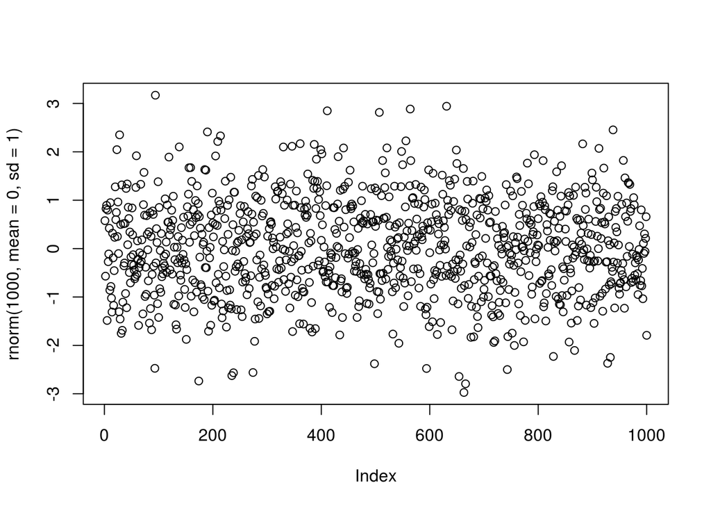

```r
plot(rnorm(1000, mean=0, sd=1))
```

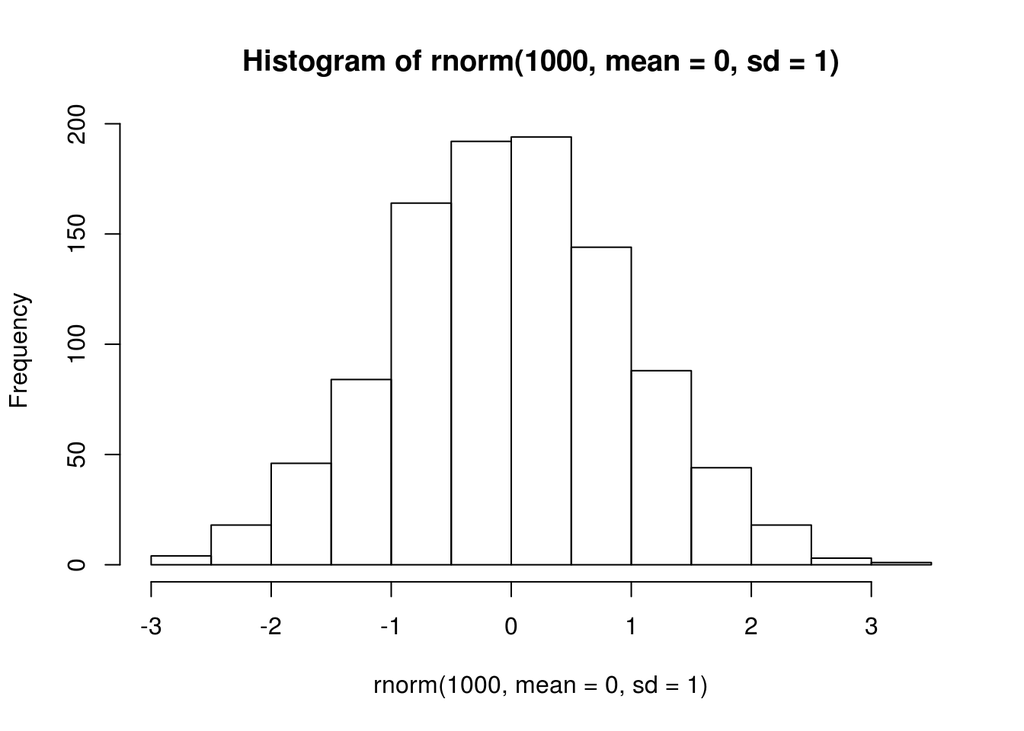

```r
hist(rnorm(1000, mean=0, sd=1))
```

## Binomial distribution

### Bernoulli distribution

`P(X=x) = p^x*(1-p)^(1-x)`

- mean = p
- variance = p(1-p)

### Binomial trials

In specific, let X1, X2, … Xn be iid Bernoulli (p) then

`X = sum(from i, till n) Xi`

is a binomial random distribution.

Binomial PMF is:

`P(X=x) = choose(n,x) * p^x * (1-p)^(n-x)`

### Examples

Suppose a friend has 8 children (oh my!), 7 of which are girls and none are twins If each gender has probability 0.5 for each birth, what is the probability of getting 7 or more girls out of 8 birth?

```r
choose(8, 7) * 0.5^8 + choose(8, 8) * 0.5^8
```

```
## [1] 0.03515625
```

```r
# or
pbinom(6, size = 8, prob = 0.5, lower.tail = FALSE)
```

```
## [1] 0.03515625
```

### Plots

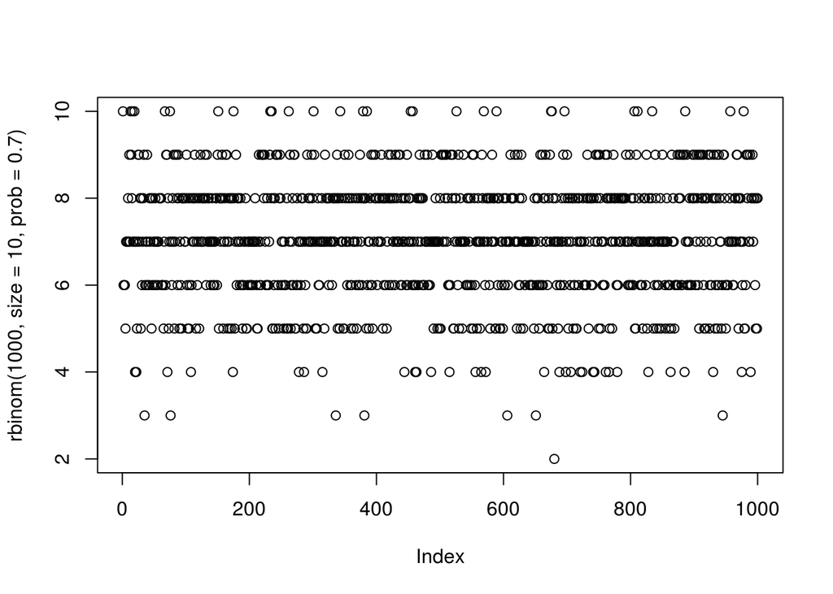

```r
plot(rbinom(1000, size=10, prob=0.70))
```

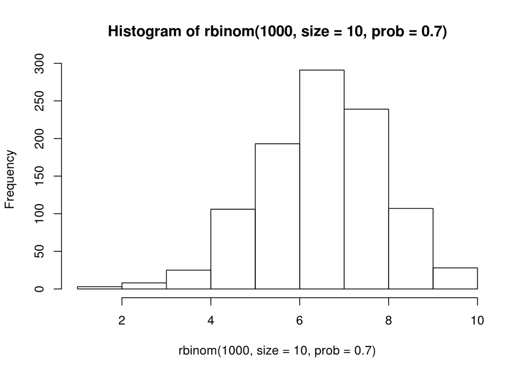

```r
hist(rbinom(1000, size=10, prob=0.70))
```